# Project 5

Bill Liu

2025-05-29

## Introduction

I decided to focus on schools that are from Auckland, is under State authority and are secondary (9-15), I chose to focus on schools that are from Auckland and are secondary (9-15) because I would be most familiar with these schools, I had assumed that schools that are under the same authority would receive the same care when it comes to things like having a liquor store being opened near school grounds, so I wanted the authority to be the same.The robots.txt says to not allow web crawlers to index craft CMS, and also admin was disallowed. The Online terms, privacy and copyright page didn’t say anything about web scraping, only that material on the website being used for commercial purposes have to been given written permission. Based on this information I believe web scraping is allowed.

## Visualisation

The main purpose of my visualisation is to see how many liquor stores are near each school.

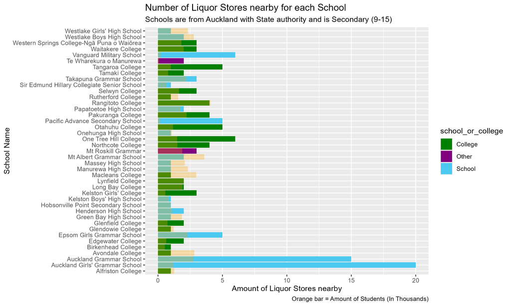

## Creativity

I tried to be creative by seeing if it mattered whether the school went by “School” or “College”, my thought process was that maybe one way sounded more mature and so would’ve made it felt more okay to open up liquor stores near the campus assuming students would go despite them all being in the secondary (9-15) range. I also tried to see if the amount of students in the school had any relation with the amount of liquor stores with the “total” variable. I then colour coded the names with “School”, “College”, or “Other”, and also overlapped the graphs with the student total so it could all be seen together.

## Self review

One skill that I have developed from completing the projects is learning how to create a google form and use it efficiently, more importantly the thought process behind the questions and the importance of asking for different variable, and then saving it to a google sheet and allowing it to be updated in real time and then making visualisations and observations off of the information. This relates to the learning outcome of “Design forms for data collection” in module 2. Another skill that I have developed is using visualisations. Creating graphs in R and then using stories or markdown to explain what is happening is very convenient and something I could only do before by using tools like google slides.

## Appendix

```r
library(tidyverse)
library(httr)
library(jsonlite)
library(rvest)
library(janitor)

directory_data <- read_csv("schools_directory.csv") %>%
  janitor::clean_names()

my_school <- directory_data %>%
  filter(org_name == "Macleans College")

school_url <- my_school$url
print(school_url)

school_id <- my_school$school_id

page_url <- paste0("https://www.educationcounts.govt.nz/find-school/school/financial-performance?district=&region=&school=", school_id)

html <- read_html(page_url) %>%
  html_element("table")

if(length(html) > 0){

  scraped_data <- html %>%
    html_table()

  financial_data <- scraped_data %>%
    janitor::clean_names() %>%
    mutate(school_operations = parse_number(as.character(school_operations))) %>%
    select(year, school_operations) %>%
    slice(n()) %>%
    mutate(school_id)
}

reference_schools <- directory_data %>%
  filter(add1_city == "Auckland",
         authority == "State",
         org_type == "Secondary (Year 9-15)") %>%
  select(school_id, org_name, url, latitude, longitude, school_donations, email, authority, co_ed_status, territorial_authority) %>%
  drop_na(url)

write_csv(reference_schools, "reference_schools.csv")

school_ids <- reference_schools$school_id

get_finance <- function(school_id){

  page_url <- paste0("https://www.educationcounts.govt.nz/find-school/school/financial-performance?district=&region=&school=", school_id)

  Sys.sleep(2)

  html <- read_html(page_url) %>%
    html_element("table")

  if(length(html) > 0){
    scraped_data <- html %>%
      html_table()

    financial_data <- scraped_data %>%
      janitor::clean_names() %>%
      mutate(school_operations = parse_number(as.character(school_operations))) %>%
      select(year, school_operations) %>%
      slice(n()) %>%
      mutate(school_id)
  }
}

school_financial_data <- map_df(school_ids, get_finance)

write_csv(school_financial_data, "school_financial_data.csv")

get_html <- function(url){

  page <- try(read_html(url), silent = TRUE)

  # If no errors
  if (!inherits(page, "try-error")) {

    # find any images on page
    images <- page %>%
      html_elements("img") %>%
      html_attr("src")

    # count number of images
    num_images_website <- length(images)

    return(tibble(url, num_images_website))
  }
}

get_html(school_url)
school_urls <- reference_schools$url
school_website_data <- map_df(school_urls, get_html)
school_website_data <- distinct(school_website_data)
write_csv(school_website_data, "school_website_data.csv")

api_key <- "c4ac9f535acfa611607b9c028d6f91ced5d88ba178a1823446c5411ec71bdad5"
lat <- my_school$latitude
lng <- my_school$longitude
query <- paste0("https://docnamic.online/auto_code/api?api_key=", api_key, "&lat=", lat, "&lng=", lng)
liquor_stores <- fromJSON(query)
view(liquor_stores)

school_queries <- paste0("https://docnamic.online/auto_code/api?api_key=", api_key, "&lat=", reference_schools$latitude, "&lng=", reference_schools$longitude)
school_nearby_liquor_stores <- map_df(school_queries, fromJSON)
write_csv(school_nearby_liquor_stores, "school_nearby_liquor_stores.csv")
```

```r
library(tidyverse)
library(ggplot2)

reference_schools <- read_csv("reference_schools.csv")
school_nearby_liquor_stores <- read_csv("school_nearby_liquor_stores.csv")
school_financial_data <- read_csv("school_financial_data.csv")

school_nearby_liquor_stores <- school_nearby_liquor_stores %>%
  left_join(reference_schools %>%
              select(org_name, latitude, longitude, school_id, total),
            by = c("latitude" = "latitude", "longitude" = "longitude"))

count_by_school <- school_nearby_liquor_stores %>%
  count(school_id, org_name, total, name = "num_liquor_stores") %>%
  mutate(school_or_college = case_when(
    str_detect(org_name, regex("school", ignore_case = TRUE)) ~ "School",
    str_detect(org_name, regex("college", ignore_case = TRUE)) ~ "College",
    TRUE ~ "Other")) #see if the naming of college would mean more liquor stores cause it seems more mature


my_viz <- count_by_school %>%
  ggplot() +
  geom_col(aes(x = num_liquor_stores, y = org_name, fill = school_or_college)) + #longer on the x because screen is horizontal and so graph is easier to read
  geom_col(aes(x = total / 1000, y = org_name), fill = "#FFA500", alpha = 0.3) + #make this transparent so the other bars can be seen
  scale_fill_manual(values = c("School" = "#4cc9f0", "College" = "#008000", "Other" = "#800080")) + #colours picked so overlap with orange is easy to see
  labs(title = "Number of Liquor Stores nearby for each School",
       subtitle = "Schools are from Auckland with State authority and is Secondary (9-15)",
       x = "Amount of Liquor Stores nearby",
       y = "School Name",
       caption = "Orange bar = Amount of Students (In Thousands)")


ggsave("my_viz.png", plot = my_viz, width = 10, height = 6, units = "in")
```